# Multiple Regression

ChatGPT 4o

2025-01-21

## 1 起源

多重回归（Multiple Regression）是对线性回归的扩展，最早由英国统计学家弗朗西斯·高尔顿（Francis Galton）和卡尔·皮尔逊（Karl Pearson）提出，主要用于研究多个自变量对因变量的影响。多重回归分析的起源可以追溯到19世纪末，最初用于遗传学的研究，之后逐渐发展并广泛应用于社会科学、经济学和医学等多个领域。

## 2 原理

多重回归分析用于探索一个因变量与多个自变量之间的线性关系。其基本形式是一个包含多个自变量的线性回归模型，旨在量化这些自变量对因变量的影响。多重回归模型的数学形式为：

$$Y = \beta_0 + \beta_1 X_1 + \beta_2 X_2 + \cdots + \beta_p X_p +
\epsilon$$

其中，$Y$ 为因变量，$X_1, X_2, \cdots, X_p$ 为自变量，$\beta_0, \beta_1, \cdots, \beta_p$ 为回归系数，$\epsilon$ 为误差项。

回归系数表示自变量对因变量的影响方向和大小，误差项则反映了模型未解释的随机误差。通过最小二乘法（Least Squares Method）估计回归系数，目的是使预测值与观测值之间的误差平方和最小化。

## 3 适用范围

多重回归适用于以下情况：

- **因变量为连续型数据**：多重回归用于预测一个连续型的因变量。
- **自变量可以是连续或分类**：自变量可以是连续型、分类变量（需转换为哑变量）或两者的组合。
- **线性关系**：适用于探索自变量和因变量之间的线性关系。
- **多变量的影响分析**：用于分析多个因素对某一因变量的综合影响。

## 4 应用情境

多重回归分析在众多领域中有着广泛的应用，例如：

- **经济学**：分析消费支出与收入、利率、教育等因素之间的关系。
- **医学研究**：研究血压与年龄、体重、运动习惯等因素之间的关系。
- **市场营销**：预测产品销量，基于广告投入、价格、竞争对手行为等因素。
- **社会科学**：分析人们的幸福感与收入、家庭结构、教育水平之间的关系。

## 5 优缺点

### 优点

- **解释多个因素的综合影响**：多重回归能够同时分析多个自变量对因变量的影响，有助于揭示复杂的关系。
- **量化自变量的影响**：可以量化每个自变量对因变量的影响方向和大小。
- **预测能力强**：多重回归能够建立一个较为全面的预测模型。

### 缺点

- **对线性假设的依赖**：假设自变量与因变量之间存在线性关系，如果关系非线性，模型的效果会受到限制。
- **对异常值敏感**：异常值可能对回归系数产生较大影响，进而影响模型的结果。
- **多重共线性问题**：当自变量之间存在高度相关性时，可能导致回归系数不稳定，影响模型的解释性。

## 6 在R中的实现及结果解释

在R中，多重回归可以通过`lm()`函数实现。以下是一个实现示例：

```r
# 示例数据：分析年龄、收入对血压的影响
set.seed(123)
Age <- rnorm(100, mean = 50, sd = 10)
Income <- rnorm(100, mean = 50000, sd = 15000)
BloodPressure <- 120 + 0.5 * Age - 0.01 * Income + rnorm(100, mean = 0, sd = 5)

# 创建数据框
data <- data.frame(Age = Age, Income = Income, BloodPressure = BloodPressure)
head(data)
```

```
##        Age   Income BloodPressure
## 1 44.39524 39343.90     -240.2473
## 2 47.69823 53853.26     -388.1214
## 3 65.58708 46299.62     -311.5284
## 4 50.70508 44786.86     -299.8001
## 5 51.29288 35725.72     -213.6825
## 6 67.15065 49324.58     -342.0518
```

```r
# 进行多重回归
multi_reg_model <- lm(BloodPressure ~ Age + Income, data = data)

# 输出结果
summary(multi_reg_model)
```

```
##
## Call:
## lm(formula = BloodPressure ~ Age + Income, data = data)
##
## Residuals:
##     Min      1Q  Median      3Q     Max
## -9.3651 -3.3037 -0.6222  3.1068 10.3991
##
## Coefficients:
##               Estimate Std. Error  t value Pr(>|t|)
## (Intercept) 123.607761   3.212807   38.473  < 2e-16 ***
## Age           0.433414   0.052435    8.266 7.29e-13 ***
## Income       -0.009992   0.000033 -302.806  < 2e-16 ***
## ---
## Signif. codes:  0 '***' 0.001 '**' 0.01 '*' 0.05 '.' 0.1 ' ' 1
##
## Residual standard error: 4.756 on 97 degrees of freedom
## Multiple R-squared:  0.9989, Adjusted R-squared:  0.9989
## F-statistic: 4.612e+04 on 2 and 97 DF,  p-value: < 2.2e-16
```

```r
str(multi_reg_model)
```

[output not shown]

```r
multi_reg_model$anova
```

```r
multi_reg_model$coefficients
```

```
##   (Intercept)           Age        Income
## 123.607760564   0.433414236  -0.009992063
```

```r
multi_reg_model$r.squared
```

```r
multi_reg_model$adj.r.squared
```

### 结果解释

运行上述代码后，将输出多重回归的结果，主要包括以下内容：

- **回归系数（Estimate）**：表示每个自变量对因变量的影响大小。正系数表示自变量增加时，因变量也增加；负系数表示自变量增加时，因变量减少。
- **标准误差（Std. Error）**：表示回归系数的不确定性。
- **t值和p值**：用于检验回归系数是否显著。如果p值小于显著性水平（如0.05），则认为该自变量对因变量具有显著影响。
- **$R^2$和调整后的$R^2$**：$R^2$表示模型对因变量变异的解释程度，调整后的$R^2$考虑了自变量个数对模型的调整，更加客观地反映模型的拟合优度。
- **Age的回归系数为0.433**：表示年龄每增加1岁，血压增加约0.433单位，且p<0.001，表明其影响显著。
- **Income的回归系数为-0.009**：表示收入每增加1单位，血压减少约0.009单位，且p<0.001，表明其影响显著。

### 结果的可视化

可以使用R中的`ggplot2`包对多重回归的结果进行可视化，以展示自变量对因变量的关系。

```r
# 加载ggplot2包
library(ggplot2)

# 绘制年龄与血压之间的关系
ggplot(data, aes(x = Age, y = BloodPressure)) +
  geom_point() +
  geom_smooth(method = "lm", se = FALSE, color = "blue") +
  labs(title = "年龄与血压之间的关系", x = "年龄", y = "血压") +
  theme_minimal()

# 绘制收入与血压之间的关系
ggplot(data, aes(x = Income, y = BloodPressure)) +
  geom_point() +
  geom_smooth(method = "lm", se = FALSE, color = "green") +
  labs(title = "收入与血压之间的关系", x = "收入", y = "血压") +
  theme_minimal()
```

[output not shown]

### 假设条件的检查

在进行多重回归分析之前，必须检查模型的假设条件，以确保结果的可靠性和有效性。常见的假设条件包括：

- **线性关系**：因变量与自变量之间应存在线性关系，可以通过绘制散点图或残差图来验证这一假设。
- **正态性**：残差应呈正态分布。可以使用`shapiro.test()`或绘制Q-Q图来检查残差的正态性。
- **同方差性（Homoscedasticity）**：残差的方差应在所有自变量的取值范围内保持一致。可以通过绘制残差与拟合值的散点图来检查同方差性。
- **独立性**：残差应相互独立。对于时间序列数据，可以使用Durbin-Watson检验来检查残差的独立性。

以下是在R中检查这些假设条件的示例：

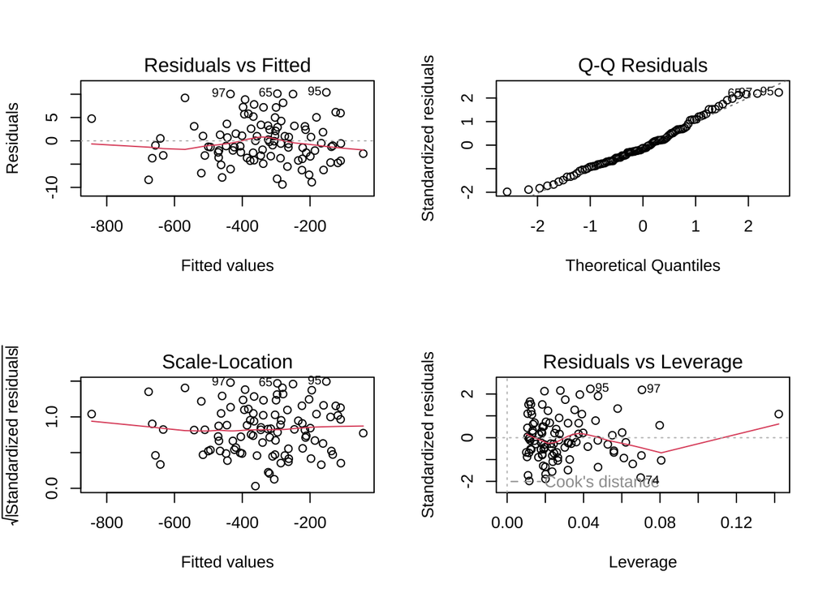

```r
# 绘制残差图以检查线性关系和同方差性
par(mfrow = c(2, 2))
plot(multi_reg_model)
```

```r
# Shapiro-Wilk正态性检验
shapiro_test <- shapiro.test(residuals(multi_reg_model))
print(shapiro_test)
```

```
##
##  Shapiro-Wilk normality test
##
## data:  residuals(multi_reg_model)
## W = 0.97815, p-value = 0.09534
```

### 多重共线性

多重共线性是指自变量之间存在高度相关性，可能导致回归系数不稳定。可以使用方差膨胀因子（Variance Inflation Factor, VIF）来检查多重共线性。如果VIF值大于10，通常认为存在严重的多重共线性。

在R中可以通过`car`包的`vif()`函数来计算VIF：

```r
# 加载car包
library(car)
# 计算VIF值
vif_values <- vif(multi_reg_model)
print(vif_values)
```

```
##      Age   Income
## 1.002459 1.002459
```

如果VIF值过高，可以考虑去除共线性较强的自变量，或者使用正则化回归（如岭回归或Lasso回归）来减轻多重共线性的问题。

### 影响点与离群值

影响点（Influential Points）和离群值（Outliers）可能对模型产生过大影响，从而导致结果失真。可以通过Cook距离（Cook’s Distance）来识别这些影响点。

以下是在R中识别影响点的示例：

```r
# 计算Cook距离
cooks_d <- cooks.distance(multi_reg_model)

# 识别影响点
influential_points <- which(cooks_d > (4 / nrow(data)))
print(influential_points)
```

```
## 16 31 64 65 74 95 97
## 16 31 64 65 74 95 97
```

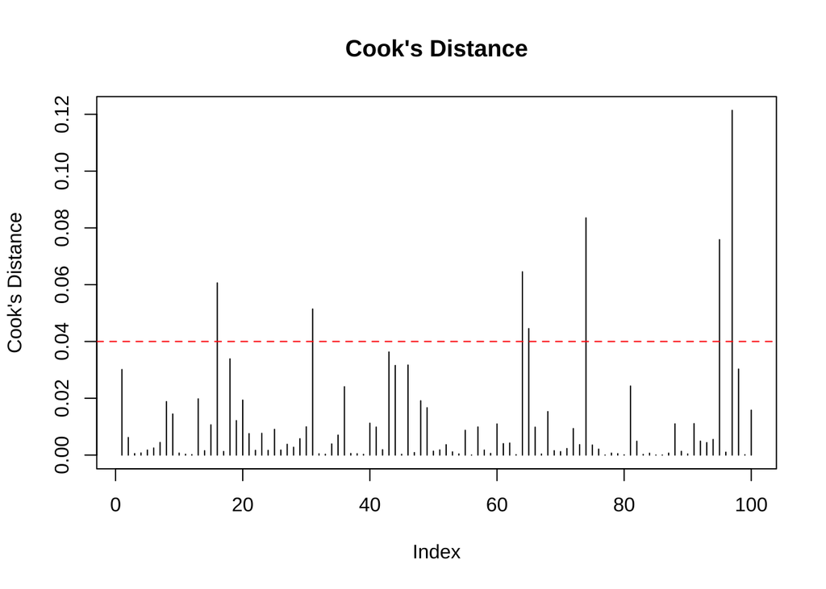

```r
# 可视化Cook距离
plot(cooks_d, type = "h", main = "Cook's Distance", ylab = "Cook's Distance")
abline(h = 4 / nrow(data), col = "red", lty = 2)
```

如果存在显著的影响点，可以考虑对这些数据点进行深入分析，确定其是否合理。如果不合理，可以考虑将其排除，以提高模型的稳健性。

### 自变量选择

在多重回归中，选择合适的自变量对提高模型的预测能力和解释力非常重要。以下是一些常用的自变量选择方法：

- **逐步回归（Stepwise Regression）**：逐步添加或移除自变量，以选择使模型拟合效果最佳的变量组合。可以使用`step()`函数来实现逐步回归。

```r
# 逐步回归进行自变量选择
stepwise_model <- step(multi_reg_model)
```

```
## Start:  AIC=314.86
## BloodPressure ~ Age + Income
##
##          Df Sum of Sq     RSS    AIC
## <none>                   2195 314.86
## - Age     1      1546    3740 366.18
## - Income  1   2074446 2076641 998.11
```

```r
summary(stepwise_model)
```

```
##
## Call:
## lm(formula = BloodPressure ~ Age + Income, data = data)
##
## Residuals:
##     Min      1Q  Median      3Q     Max
## -9.3651 -3.3037 -0.6222  3.1068 10.3991
##
## Coefficients:
##               Estimate Std. Error  t value Pr(>|t|)
## (Intercept) 123.607761   3.212807   38.473  < 2e-16 ***
## Age           0.433414   0.052435    8.266 7.29e-13 ***
## Income       -0.009992   0.000033 -302.806  < 2e-16 ***
## ---
## Signif. codes:  0 '***' 0.001 '**' 0.01 '*' 0.05 '.' 0.1 ' ' 1
##
## Residual standard error: 4.756 on 97 degrees of freedom
## Multiple R-squared:  0.9989, Adjusted R-squared:  0.9989
## F-statistic: 4.612e+04 on 2 and 97 DF,  p-value: < 2.2e-16
```

- **AIC/BIC准则**：使用Akaike信息准则（AIC）或贝叶斯信息准则（BIC）来选择最佳模型。这些准则可以帮助平衡模型的复杂度和拟合度，值越小表示模型越优。
- **岭回归和Lasso回归**：当存在多重共线性时，可以使用正则化方法（如岭回归和Lasso回归）来选择自变量。这些方法通过对系数进行惩罚来减少多重共线性对模型的影响。

### 模型比较

在构建多重回归模型时，可能需要比较多个模型以确定最优模型。常见的模型比较方法包括：

- **AIC/BIC**：通过比较不同模型的AIC/BIC值来选择最优模型，AIC/BIC值越小表示模型越优。

```r
# 比较两个模型的AIC值
model1 <- lm(BloodPressure ~ Age + Income, data = data)
model2 <- lm(BloodPressure ~ Age, data = data)
AIC(model1, model2)
```

```
##        df       AIC
## model1  4  600.6438
## model2  3 1283.8969
```

- **$R^2$ 和调整后的$R^2$**：$R^2$ 表示模型对因变量变异的解释程度，调整后的$R^2$ 可以更好地衡量模型的复杂度和拟合效果。
- **F检验**：用于比较嵌套模型，判断新增的自变量是否显著提高了模型的拟合度。

```r
# 比较两个嵌套模型的F检验
anova(model2, model1)
```

```
## Analysis of Variance Table
##
## Model 1: BloodPressure ~ Age
## Model 2: BloodPressure ~ Age + Income
##   Res.Df     RSS Df Sum of Sq     F    Pr(>F)
## 1     98 2076641
## 2     97    2195  1   2074446 91691 < 2.2e-16 ***
## ---
## Signif. codes:  0 '***' 0.001 '**' 0.01 '*' 0.05 '.' 0.1 ' ' 1
```

如果F检验结果显示p值小于显著性水平（如0.05），则认为较复杂的模型显著优于简单模型。

## 7 小结

- 多重回归用于探索一个因变量与多个自变量之间的线性关系，可以同时分析多个因素对因变量的综合影响。
- 适用于因变量为连续型的情境，能够量化每个自变量对因变量的影响方向和大小。
- 具有预测能力强、解释多个因素的综合影响的优点，但对线性假设、异常值和多重共线性较为敏感。
- 可以通过R中的`lm()`函数实现多重回归，并结合可视化更直观地展示结果。
- 在经济学、医学、市场营销和社会科学等多个领域中具有广泛的应用价值。